# Ausfallanalyse — Kohnen head03 & head04 (Winter 2026)

## Netz- und Vertragsstatus (Cloudloop-API)

Beide Subscriptions sind aktiv (Vertrag bis 06.03.2027); `lastSeen` deckt sich mit der letzten Message — das Netz sieht die Geräte seither gar nicht mehr (keine abgewiesenen Sessions). Der Block fragt den Status bei jedem Render live ab; ohne Token/Internet wird er übersprungen. Ob die Modems noch *erfolglose* Sessionversuche machen, sieht nur der Ground-Control-Support (Anfrage gestellt).

```r
SUBS <- c("head03 (231709)" = "olNGxekOvAKmanjJDQDnRdpyLgXjMbVP",
          "head04 (231710)" = "JaKzYmyeDdjGPWarNJdELrlVqgZxNXAp")
tokf <- "../cloudloop/.token"
res <- tryCatch({
  tok <- Sys.getenv("CLOUDLOOP_TOKEN", unset = NA)
  if (is.na(tok) || !nzchar(tok)) tok <- trimws(readLines(tokf, warn = FALSE)[1])
  rows <- lapply(names(SUBS), function(nm) {
    r <- httr2::request("https://api.cloudloop.com/Sbd/GetSubscriber") |>
      httr2::req_url_query(token = tok, subscriber = SUBS[[nm]]) |>
      httr2::req_method("POST") |> httr2::req_retry(max_tries = 3) |>
      httr2::req_perform(verbosity = 0) |> httr2::resp_body_json()
    s <- r$subscriber
    data.frame(Head = nm, IMEI = s$hardware$imei,
               Status = s$contract$networkStatus,
               `Vertrag bis` = substr(s$contract$committedTo, 1, 10),
               lastSeen = sub("T", " ", substr(s$lastSeen, 1, 16)),
               check.names = FALSE)
  })
  do.call(rbind, rows)
}, error = function(e) NULL)
if (is.null(res)) {
  cat("*Cloudloop-API nicht erreichbar (Token/Internet) — Status-Abfrage übersprungen.*\n")
} else {
  print(knitr::kable(res))
}
```

| Head | IMEI | Status | Vertrag bis | lastSeen |
| --- | --- | --- | --- | --- |
| head03 (231709) | 301434062513730 | ACTIVATED | 2027-03-06 | 2026-07-22 09:03 |
| head04 (231710) | 301434062514750 | ACTIVATED | 2027-03-06 | 2026-08-13 17:36 |

## Wetter am Standort (ERA5T)

Tagesmaxima von 10-m-Wind, Böen und 2-m-Temperatur am Kohnen-Gitterpunkt (75.0° S, 0.07° O), bei jedem Render frisch von der Open-Meteo-Archiv-API (ERA5/ERA5T, ~5 Tage hinter Echtzeit). Gestrichelt: die letzten Messages der beiden Heads.

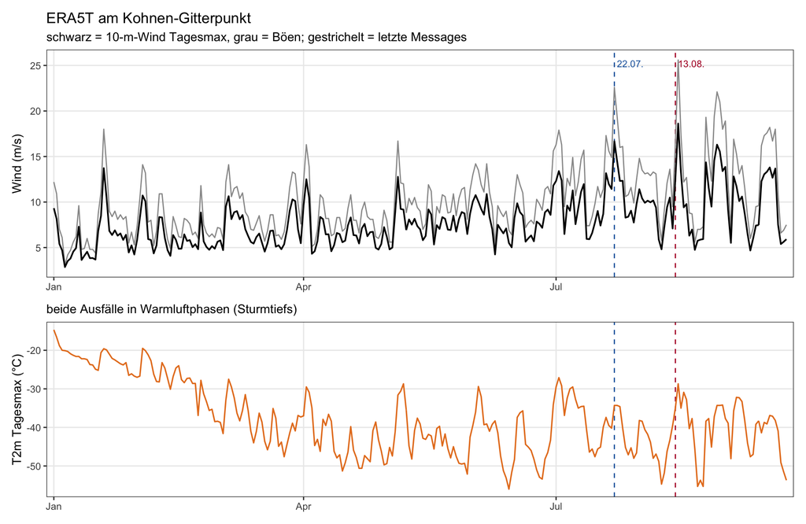

```r
wind <- tryCatch({
  u <- paste0("https://archive-api.open-meteo.com/v1/archive",
              "?latitude=-75.0&longitude=0.07",
              "&start_date=2026-01-01&end_date=", format(Sys.Date() - 2, "%Y-%m-%d"),
              "&daily=wind_speed_10m_max,wind_gusts_10m_max,temperature_2m_max",
              "&timezone=UTC&wind_speed_unit=ms")
  j <- jsonlite::fromJSON(u)$daily
  tibble(day = as.Date(j$time), wind = j$wind_speed_10m_max,
         gust = j$wind_gusts_10m_max, t2m = j$temperature_2m_max) |>
    filter(!is.na(wind))
}, error = function(e) NULL)

if (is.null(wind)) {
  cat("ERA5T/Open-Meteo nicht erreichbar — Wetterabschnitt übersprungen.\n")
} else {
  vl <- as.Date(ends$last)
  pw <- ggplot(wind, aes(day)) +
    geom_vline(xintercept = vl, linetype = "dashed", colour = unname(cols)) +
    geom_line(aes(y = gust), colour = "grey60", linewidth = 0.5) +
    geom_line(aes(y = wind), colour = "black", linewidth = 0.7) +
    annotate("text", x = vl, y = max(wind$gust, na.rm = TRUE),
             label = format(ends$last, " %d.%m."), hjust = 0, vjust = 1,
             size = 3, colour = unname(cols)) +
    scale_x_date(NULL, expand = c(0.01, 0)) +
    labs(y = "Wind (m/s)",
         title = "ERA5T am Kohnen-Gitterpunkt",
         subtitle = "schwarz = 10-m-Wind Tagesmax, grau = Böen; gestrichelt = letzte Messages") +
    theme_bw(11) + theme(panel.grid.minor = element_blank())
  pt <- ggplot(wind, aes(day, t2m)) +
    geom_vline(xintercept = vl, linetype = "dashed", colour = unname(cols)) +
    geom_line(colour = "#e67e22", linewidth = 0.6) +
    scale_x_date(NULL, expand = c(0.01, 0)) +
    labs(y = "T2m Tagesmax (°C)",
         subtitle = "beide Ausfälle in Warmluftphasen (Sturmtiefs)") +
    theme_bw(11) + theme(panel.grid.minor = element_blank())
  pw / pt + plot_layout(heights = c(1.3, 1))
}
```

```r
if (!is.null(wind)) {
  for (i in seq_len(nrow(ends))) {
    d0 <- as.Date(ends$last[i])
    w <- wind |> filter(day >= d0 - 1, day <= d0 + 1)
    if (nrow(w)) cat(sprintf(
      "- **%s** (letzte Message %s): Wind-Tagesmax um den Ausfall **%.1f m/s**, Böen **%.1f m/s**, T2m-max **%.1f °C**.\n",
      ends$head[i], format(ends$last[i], "%d.%m. %H:%M"),
      max(w$wind), max(w$gust), max(w$t2m)))
  }
  rk <- wind |> mutate(r = rank(-gust)) |> filter(day %in% as.Date(ends$last) |
         day %in% (as.Date(ends$last) + 1))
  cat(sprintf("\nDie Ausfalltage (±1 Tag) belegen die Böen-Ränge **%s** von %d Tagen seit dem 01.01.2026.\n",
              paste(sort(round(rk$r)), collapse = ", "), nrow(wind)))
}
```

- **head03 (231709)** (letzte Message 22.07. 09:03): Wind-Tagesmax um den Ausfall **16.7 m/s**, Böen **22.6 m/s**, T2m-max **-34.3 °C**.
- **head04 (231710)** (letzte Message 13.08. 17:38): Wind-Tagesmax um den Ausfall **18.6 m/s**, Böen **25.6 m/s**, T2m-max **-28.7 °C**.

Die Ausfalltage (±1 Tag) belegen die Böen-Ränge **1, 2, 6, 21** von 265 Tagen seit dem 01.01.2026.

## Schadensbild am Modem (ESD-Hypothese im Detail)

**Der Puls:** Antenne + Koaxkabel (~100 pF/m, bei ~10 m ≈ 1 nF) laden sich im Driftschnee auf einige kV auf. Die Aufladung ist dabei ein *Dauerprozess* über die Blizzard-Dauer (Ladungs-Masse-Verhältnisse der Partikel +72 bis −208 µC/kg, Felder bis 30 kV/m; Luftfahrt-Analogie: 100–760 µA Dauerladestrom). Für ein kleines, ortsfestes Objekt liegt der Auftreffstrom nach der Skalierung I = Q·C·V·A allerdings eher bei **nA–µA** — genug für kV an isolierten Teilen, zu wenig für Dauer-Watt; die Größenordnung ist offen und soll im Neumayer-Test gemessen werden (siehe `esd_schutz_und_teststrategie.md`). Beim Überschlag entlädt sich das in Nanosekunden über den Innenleiter — Spitzenströme im 10-A-Bereich, Energie im mJ-Bereich. DC-Blockkondensatoren im Signalpfad sind für ns-Transienten durchlässig.

**Was stirbt:** Hinter dem Antennenpin des 9602/9603 sitzen T/R-Schalter, Filter und LNA-Eingang. Deren Transistorstrukturen brechen bei wenigen Volt durch; RF-Pins tragen bewusst nur minimale ESD-Strukturen (einige 100 V), weil Schutzdioden Kapazität kosten und die Rauschzahl verschlechtern. Ein kV-Puls liegt zwei bis drei Größenordnungen darüber: Gateoxid-Durchbruch, durchlegierte Übergänge. Äußerlich unsichtbar — der Schaden ist nanometerskalig.

**Mögliche Endzustände** (von außen identisch = Funkstille):

1. Hard kill — LNA/Schalter zerstört: Empfänger taub, keine Netzakquisition.
2. Degradation — Rauschzahl um 10–20 dB verschlechtert: Linkmarge weg, jede Session scheitert.
3. Antennenseite — Anpassnetzwerk des Patches zerstört: Antenne total reflektiv, Modem intakt, kein Link.

**Der Digitalteil lebt vermutlich weiter:** ESD über den RF-Port tötet das Frontend, nicht den Prozessor. Logger und Messkette laufen sehr wahrscheinlich normal weiter — messen, senden erfolglos. Wir sehen davon nichts, weil die gesamte Telemetrie durch den zerstörten Kanal müsste.

## Konsequenz: Daten liegen auf SD — Winterrecord rettbar

**Beide Heads loggen lokal auf SD-Karte.** Wenn die ESD-Hypothese stimmt (Logger lebt, nur der Iridium-Pfad ist tot), messen beide Ketten seit dem 22.07. bzw. 13.08. normal weiter und der komplette Winterrecord liegt vor Ort — nichts ist verloren, nur die Live-Übertragung fehlt.

**Checkliste Sommerbesuch — Phase 1 (wenige Stunden, Person ohne Systemkenntnis; Modem verlötet, Ketten-PicoBlades bleiben unberührt — Details und Phase 2 in `esd_schutz_und_teststrategie.md`):**

- Foto-Doku Mast/Antenne/Abspannung (Überschlagspuren).
- **NanoVNA am oberen Kabelende** (Preset + Bildschirmfoto): unterscheidet Antenne defekt / Pfad unten defekt und prüft das Kabel gleich mit.
- **Antenne tauschen** (Ohmmeter-verifizierte Ersatz-TW3600); alte Antenne mit zur Forensik.
- Elektronik **hochziehen, SD kopieren/tauschen**, wieder ablassen — Kettenstecker nicht anfassen.
- Besuch um einen **Sendeslot** planen (head03 09:03/21:03 UTC, head04 17:38 UTC) und Erfolg live in Cloudloop prüfen.
- Fallnetz: Lebt die Elektronik, läuft die Messung auch ohne Telemetrie weiter (jährliche SD-Bergung); Kompletttausch mit GDT-geschützten Werkstatt-Einheiten folgt in Phase 2.